# Hoja de Ejercicios 3

Aprendizaje Estadístico y Toma de Decisiones.

Juan José Martín, Marina Moreno, Christian Strasser, Maria del Mar Bibiloni.

```r
library(stats)
library(ggplot2)
```

# Ejercicio 9

**Nos interesa estimar una regresión logística en la que queremos explicar una variable binomial (0,1) con una variable $X$. Por el problema de endogenidad, lo estimamos en 2 etapas. En la primera etapa en vez de regresar $Y$ sobre $X$, primero se hace una regresión de $X$ sobre cualquier combinación de instrumentos posibles $\{Z_1,Z_2,Z_3\}$ y se guarda el valor ajustado $\tilde{X}$, después se hace una regresión de la variable continua $Y$ sobre $\tilde{X}$.**

El método de las variables instrumentales se utiliza cuando puede existir correlación entre la variable independiente y el término de error. Para evitar que esto suceda, se busca una/s variable/s instrumental/es $Z$ de manera que $Corr(Y,Z)=0$ pero que $Corr(X,Z)\neq 0$.

El método se basa en buscar cuál es la mejor regresión ($\tilde{X}$) de la variable independiente $X$ con las variables instrumentales $Z_i$ de manera que el error en la regresión $Y$ sobre $\tilde{X}$ sea mínimo. Para saber con qué variables instrumentales es mejor realizar la regresión sobre $X$ utilizaremos el método de validación cruzada con dos etapas.

1. **Explica cómo se utilizaría la validación cruzada para evaluar que combinación de instrumentos da los mejores resultados.**

El problema a resolver es el siguiente:

$$\tilde{X} = \alpha Z_1 +\beta Z_2 +\gamma Z_3$$

Vamos a seleccionar con validación cruzada cuál es la mejor combinación de variables instrumentales para predecir $Y$ sobre $\tilde{X}$, es decir, qué coeficientes $\alpha, \beta, \gamma$ igualamos a 1 o anulamos para obtener una predicción final mejor. Notemos que tenemos $2^3=8$ combinaciones para anular o mantener los coeficentes anteriores y en consecuencia tenemos 8 modelos posibles.

Se realizaran 5 (o 10) particiones de los datos, y en cada modelo se realiazará la regresión $Y$ sobre $\tilde{X}$ (que estemos considerando) con 4 de los 5 trozos de los datos y con el quinto trozo se calculará el error de predicción. Manteniendo la misma partición, se volverá a calcular la regresión $Y$ sobre $\tilde{X}$, pero esta vez cambiando el trozo de validación. En consecuencia tendremos 5 errores de predicción para cada modelo de $\tilde{X}$, uno para cada trozo de la partición que hemos dejado para calcular el error de predicción. Se suman estos 5 errores y así obtenemos el error de predicción del modelo con el que estabamos trabajando.

Este mismo proceso se realiza con los otros siete modelos posibles restantes y nos quedamos con el que obtengamos un error de predicción mínimo.

2. **Explica cómo se utilizaría el bootstrap para calcular la desviación estándar del coeficiente de regresión de $Y$ sobre $X$.**

Una vez tenemos el modelo de regresión $Y = \alpha X$ , queremos saber cómo es de fiable el parámetro $\alpha$ que hemos estimado. Para ello cogeremos 1000 muestras aleatorias simples de los datos de los que disponemos con reemplazo y calculamos para cada m.a.s. el coeficiente de la regresión. Una vez tengamos estimados el coeficiente $\alpha$ para cada regresión calculamos su desviación típica del vector de coeficientes. De este modo obtendremos la desviación estándar del coeficiente de regresión de $Y$ sobre $X$.

# Ejercicio 10

**Dibuja el resultado de una predicción de 2 vecinos más cercanos de una regresión de los puntos en un examen sobre horas estudiadas. ¿Cómo te parece la elección de $K=2$?**

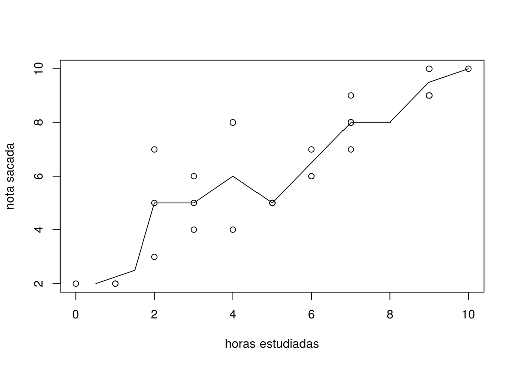

Dentro de un conjunto de muestras como el anterior, el resultado de realizar una predicción de sólamente 2 vecinos más cercanos puede resultar en un sobreajuste del conjunto de muestras, lo cual no aporta mucha utilidad ya que si fueramos a utilizar esta predicción sobre futuras muestras, sería muy probable que la predicción sea errónea.

# Ejercicio 11

**Analizamos 3 variables con la matriz de correlaciÛn dada por**

$$\begin{pmatrix}
1 & 0.1 & -0.05\\
0.1 & 1 & -0.1 \\
-0.05 & -0.1 & 1
\end{pmatrix}$$

1. **¿Tiene sentido hacer un análisis de componentes principales?**

No tiene mucho sentido hacer un análisis de componentes principales sobre un conjunto de variables que no tienen casi correlación entre ellas, como es el caso anterior.

2. **¿Cuántos componentes principales crees que encontramos (elegimos)?**

Como casi no existe correlación entre las variables, obtendriamos 3 componentes principales (todos).

3. **¿Qué porcentaje de la varianza total explica aproximadamente cada componente principal?**

Cada componente principal explicaría alrededor de $1/3$ de varianza total por el motivo explicado en los apartados a) y b).

# Ejercicio 13

**Te gustaría invertir dinero en acciones. Algún amigo comenta que acciones de tecnologia han crecido los últimos años más rápidamente. Sin embargo quieres basar tu decisión en datos y comparas los rendimientos de acciones de tecnología con los demás. Encuentras que la diferencia es positiva y altamente significativa. Por eso inviertes. Te parece bien el análisis?**

En primer lugar, debemos comentar que el estudio que quiere realizar la persona que quiere invertir es insuficiente y elemental. Nosotros propondríamos un estudio basado en buscar correlaciones positivas y negativas en diferentes sectores y que estos sectores fueran más específicos (y no: o tecnnolgia o no tecnologia). Además en el supuesto del eunciado no se contempla el hecho de que se pueda producir un suceso externo que provoque la caída del precio de las acciones.

En segundo lugar, el sujeto del enunciado que quiere invertir peca en una de las pautas básicas para la creación de cualquier modelo. Se supone que el individuo realiza un modelo con datos históricos pero en ningún momento se verifica o contrasta con datos nuevos para obtenerun error de predicción y saber cómo de bueno es el modelo.

En conclusión, el análisis que se realiza no nos parece bien, ya que es necesario la obtención de nuevos datos para poder dar el modelo como válido.

# Ejercicio 14

En primer lugar, observemos que todas las variables estan medidas sobre una misma unidad de medida, en consecuencia no seria necesario escalar los datos con desviación estandar a 1, aunque se puede realizar.

# Ejercicio 15

**Utiliza los datos, en el fichero “satisfacción” y haz un análisis de componentes principales.**

El fichero *satisfaccion* contiene el nivel de satisfacción de varios turistas que realizaron sus vacaciones en Baleares en agosto de 2003. Este nivel, respecto las siguientes características (variables), se mide de 1 (pésimo) a 10 (excelente).

- *PAISAJE*: nivel de satisfacción respecto al paisaje.
- *PLAYA*: nivel de satisfacción respecto a la playa.
- *CLIMA*: nivel de satisfacción respecto al clima.
- *CALALOJ*: nivel de satisfacción respecto a la calidad del alojamiento.
- *CALMEDIO*: nivel de satisfacción respecto a la calidad medioambiental.
- *CALURBAN*: nivel de satisfacción respecto a la calidad del entorno urbano.
- *LIMPIEZA*: nivel de satisfacción respecto a la limpieza.
- *PRCOMID*: nivel de satisfacción respecto al precio de las comidas.
- *PROCIO*: nivel de satisfacción respecto al precio de las actividades de ocio.
- *PRCOMPRA*: nivel de satisfacción respecto al precio de compras comerciales.
- *TRATO*: nivel de satisfacción respecto al trato recibido como cliente.
- *HOSPIT*: nivel de satisfacción respecto a la hospitalidad de la gente.
- *SEGUR*: nivel de satisfacción respecto a la seguridad.
- *DIVERS*: nivel de satisfacción respecto a la diversión nocturna.
- *INFORM*: nivel de satisfacción respecto a la información.
- *SEÑAL*: nivel de satisfacción respecto a la señalización.
- *CULTURA*: nivel de satisfacción respecto a actividades y atractivos culturales.
- *TRANQUIL*: nivel de satisfacción respecto a la tranquilidad.
- *RUIDO*: nivel de satisfacción respecto al ruido.

Veamos la satisfacción de algunos turistas.

```r
pcegt_satisfaccion = as.data.frame(pcegt_satisfaccion)
head(pcegt_satisfaccion)
```

| satisglo | paisaje | playa | clima | calaloj | calmedio | calurban | limpieza | prcomid | procio | prcompra | trato | hospit | segur | divers | inform | señal | cultura | tranquil | ruido | volver | semana | aloj3 | zona2 | agencia | profes2 | nacion | volver2 |
| --- | --- | --- | --- | --- | --- | --- | --- | --- | --- | --- | --- | --- | --- | --- | --- | --- | --- | --- | --- | --- | --- | --- | --- | --- | --- | --- | --- |
| 8 | 10 | 5 | 8 | 10 | 5 | 5 | NA | 4 | 5 | 5 | NA | 8 | 8 | NA | NA | NA | NA | 8 | NA | 1 | 1 | NA | 5 | 0 | 1 | 1 | 1 |
| 8 | 9 | 5 | 10 | NA | 3 | 8 | 5 | 1 | 3 | 3 | 8 | 8 | 8 | 10 | 8 | NA | 8 | 7 | 2 | 1 | 1 | 5 | 1 | 0 | 1 | 1 | 1 |
| NA | 10 | 5 | 8 | 10 | 3 | 3 | 3 | 4 | 3 | 4 | 3 | 3 | 8 | NA | 8 | 8 | 8 | 8 | 3 | 1 | 1 | 5 | 1 | 1 | 1 | 1 | 1 |
| 9 | 8 | 8 | 8 | 1 | 8 | 8 | 8 | 8 | 8 | 7 | 8 | 8 | 8 | 8 | 1 | 1 | 8 | 8 | 8 | 1 | 1 | 5 | 2 | 0 | 1 | 1 | 1 |
| NA | 9 | 7 | 7 | 6 | 8 | 9 | 7 | 6 | 5 | 6 | 7 | 8 | 9 | 6 | 6 | 7 | 6 | 8 | 9 | NA | 1 | 4 | 8 | 1 | 1 | 1 | NA |
| 3 | 2 | 2 | 6 | 4 | 3 | 4 | 4 | 6 | 1 | 1 | 3 | 3 | 2 | 1 | 2 | 3 | 1 | 6 | 6 | 2 | 1 | 4 | 7 | 1 | 2 | 1 | 0 |

Como podemos observar, hay algunas filas vacías, por lo que las quitamos para hacer el análissi de componentes principales.

```r
satisfaccion = pcegt_satisfaccion[complete.cases(pcegt_satisfaccion), ]
```

```r
apply(satisfaccion, 2, var)
```

```
##  satisglo   paisaje     playa     clima   calaloj  calmedio  calurban
## 3.1324490 3.8862132 4.3123103 3.4896869 4.9665044 3.6949588 3.4458435
##  limpieza   prcomid    procio  prcompra     trato    hospit     segur
## 4.3557953 5.2625996 4.6881891 4.2459439 4.8947713 4.8932761 4.3494161
##    divers    inform     señal   cultura  tranquil     ruido    volver
## 6.0030073 4.7064045 4.6531357 4.5749675 5.9341587 6.8800990 0.1394017
##    semana     aloj3     zona2   agencia   profes2    nacion   volver2
## 0.3616871 1.3702728 5.8874947 0.1923410 1.6787831 1.3346666 0.1394017
```

Calculemos las componentes principales.

```r
pc_satisfaccion = prcomp(satisfaccion, scale=TRUE)
ncol(pc_satisfaccion$rotation)
```

```
## [1] 28
```

Tenemos 28 componentes principales.

Ahora, visualizamos parte de la matriz de vectores de carga de los componentes principales.

```r
head(as.data.frame(pc_satisfaccion$rotation))
```

| PC1 | PC2 | PC3 | PC4 | PC5 | PC6 | PC7 | PC8 | PC9 | PC10 | PC11 | PC12 | PC13 | PC14 | PC15 | PC16 | PC17 | PC18 | PC19 | PC20 | PC21 | PC22 | PC23 | PC24 | PC25 | PC26 | PC27 | PC28 |
| --- | --- | --- | --- | --- | --- | --- | --- | --- | --- | --- | --- | --- | --- | --- | --- | --- | --- | --- | --- | --- | --- | --- | --- | --- | --- | --- | --- |
| -0.2623935 | 0.088063919 | -0.10734273 | 0.03685868 | -0.04627867 | 0.07759906 | 0.05006691 | -0.10217150 | -0.04714600 | 0.03895966 | 0.24169239 | -0.10232398 | -0.17206615 | -0.08078131 | 0.20137769 | 0.10362199 | -0.01054074 | -0.112957403 | -0.04886854 | -0.24311823 | 0.72810991 | -0.0254450 | -0.28936286 | -0.012044686 | 0.16959759 | 0.01318700 | -0.10670373 | -6.340747e-16 |
| -0.2082380 | -0.144736075 | -0.16000578 | 0.08102625 | 0.02154875 | -0.12898996 | 0.14568869 | 0.03133825 | 0.10349621 | 0.09718947 | 0.01849435 | 0.05995443 | 0.40335020 | 0.26674818 | 0.05565787 | 0.26346808 | 0.61448072 | 0.283679723 | -0.05717483 | 0.11573767 | 0.03711519 | 0.1629045 | -0.11746428 | -0.056185257 | 0.08126639 | -0.06110282 | 0.06185037 | 2.223541e-16 |
| -0.1941204 | -0.103156059 | -0.09963747 | 0.09172928 | 0.02545684 | -0.10804781 | 0.37297011 | -0.20969749 | 0.14272382 | 0.05066181 | 0.27092079 | -0.05838221 | 0.09794227 | 0.21052523 | -0.18513874 | 0.38553353 | -0.30552186 | -0.501960541 | -0.01047517 | 0.02716570 | -0.17882119 | 0.0132222 | 0.06959700 | 0.004511558 | -0.13013229 | 0.01831727 | 0.03035164 | 3.607651e-16 |
| -0.1978377 | -0.133387790 | -0.02874635 | 0.05380395 | 0.06639582 | -0.05581386 | 0.23878014 | -0.13132559 | 0.04385961 | -0.01753155 | 0.46984496 | -0.15926004 | 0.07304821 | 0.12518864 | -0.02144024 | -0.59271523 | -0.20207907 | 0.423160754 | 0.09060171 | 0.01221071 | -0.05002436 | -0.0119187 | 0.01825269 | -0.028294420 | -0.05602136 | -0.02932609 | -0.01992610 | 1.098091e-16 |
| -0.2293061 | -0.008761945 | -0.10413331 | 0.01655965 | -0.04364347 | 0.22906302 | 0.07919980 | 0.03201490 | -0.10305076 | -0.11518058 | 0.14405040 | -0.16867376 | -0.32652593 | -0.19108856 | 0.48935978 | 0.06435374 | 0.18620005 | -0.008827336 | -0.32377084 | 0.01524436 | -0.28859763 | 0.1525835 | 0.21559413 | -0.145425532 | -0.21351026 | 0.10154075 | 0.21168558 | -1.118910e-16 |
| -0.2554703 | -0.193616627 | -0.08857725 | 0.16459126 | -0.21195526 | 0.02571907 | 0.13410962 | -0.02596152 | 0.05433292 | 0.05603953 | -0.19090353 | -0.06469540 | -0.06575187 | -0.17928328 | 0.10638937 | -0.04546865 | -0.01879537 | -0.019112519 | 0.02857029 | 0.03860041 | -0.30485386 | -0.2661540 | -0.02823177 | 0.265989866 | 0.65489119 | 0.09419683 | -0.15934107 | 5.793235e-17 |

Con la función *Summary*, podemos ver la proporción de varianza explicada y la proporción de varianza acumulada.

```r
sum_pc = summary(pc_satisfaccion)
sum_pc
```

```
## Importance of components:
##                           PC1     PC2     PC3     PC4    PC5     PC6
## Standard deviation     2.7802 1.39970 1.33627 1.18113 1.0858 1.06834
## Proportion of Variance 0.2761 0.06997 0.06377 0.04982 0.0421 0.04076
## Cumulative Proportion  0.2761 0.34603 0.40980 0.45962 0.5017 0.54249
##                            PC7     PC8     PC9    PC10    PC11    PC12
## Standard deviation     1.04648 1.02590 0.98223 0.96669 0.93349 0.90831
## Proportion of Variance 0.03911 0.03759 0.03446 0.03337 0.03112 0.02947
## Cumulative Proportion  0.58160 0.61919 0.65364 0.68702 0.71814 0.74761
##                           PC13    PC14    PC15    PC16    PC17    PC18
## Standard deviation     0.89095 0.86797 0.82745 0.77978 0.73798 0.72229
## Proportion of Variance 0.02835 0.02691 0.02445 0.02172 0.01945 0.01863
## Cumulative Proportion  0.77596 0.80286 0.82731 0.84903 0.86848 0.88711
##                           PC19    PC20    PC21    PC22    PC23    PC24
## Standard deviation     0.69892 0.68223 0.62115 0.61184 0.59714 0.55460
## Proportion of Variance 0.01745 0.01662 0.01378 0.01337 0.01273 0.01098
## Cumulative Proportion  0.90456 0.92118 0.93496 0.94833 0.96107 0.97205
##                           PC25    PC26    PC27      PC28
## Standard deviation     0.53827 0.50181 0.49094 1.235e-15
## Proportion of Variance 0.01035 0.00899 0.00861 0.000e+00
## Cumulative Proportion  0.98240 0.99139 1.00000 1.000e+00
```

La proporcion de varianza explicada es poca para los primeros componentes. Veámoslo en un gràfico.

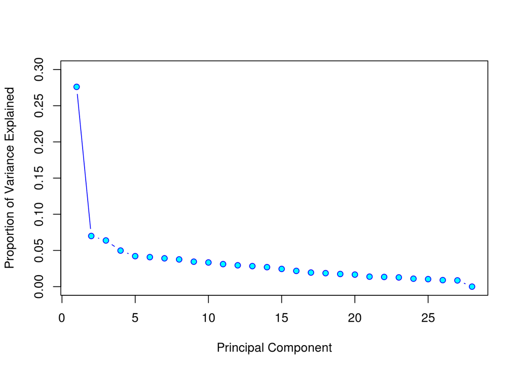

```r
plot(1:28, sum_pc$importance[2,], xlab="Principal Component", ylab="Proportion of Variance Explained",
     ylim=c(0,0.3), pch=21, type='b', bg="cyan", col="blue")
```

Aunque no es suficiente para explicar los datos, vemos como el primer compoente es el que más explica con diferencia.

Ahora, la idea es usar la proporción de varianza explicada acumulada para ver que componentes son suficientes para explicar la satisfacción de los turistas. Así, tomaremos las componentes que expliquen más de un $80\%$ de los datos. Visualicemos las proporciones.

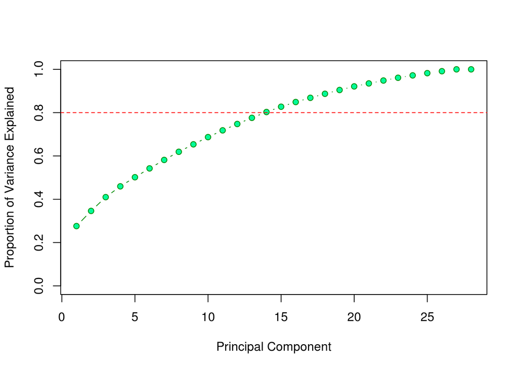

```r
plot(1:28, sum_pc$importance[3,], xlab="Principal Component", ylab="Proportion of Variance Explained",
     ylim=c(0,1), pch=21, type='b', bg="mediumspringgreen", col="green4" )
abline(h=0.8, col="red", lty="dashed")
```

Parece que podriamos reducir la dimensión hasta 14 componentes principales. Comprobémoslo.

```r
which(sum_pc$importance[3,] >= 0.8)[1]
```

```
## PC14
##   14
```

El valor de proporción aculada para esta componente 14 es 0.80286.

Aunque no podemos dibujar las 14 componentes principales, sí podemos representar las dos primeras tal como sigue.

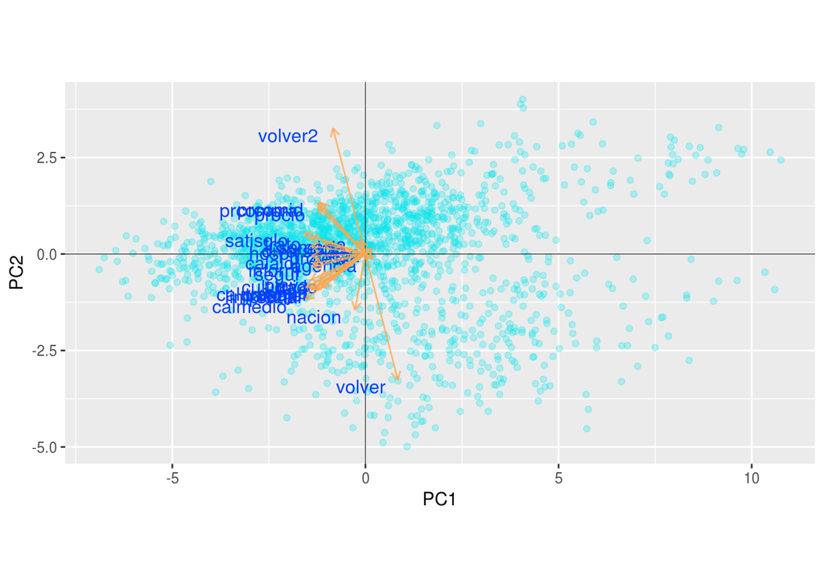

```r
PCbiplot = function(PC, x="PC1", y="PC2", colors=c('black', 'black', 'red', 'red')) {
        data = data.frame(obsnames=row.names(PC$x), PC$x)

        plot = ggplot(data, aes_string(x=x, y=y)) +
          geom_point(alpha = 0.25, col="turquoise2")

        plot = plot +
          geom_hline(yintercept = 0,aes(0), size=.2) +
          geom_vline(aes(0), size=.2, color=colors[2], xintercept = 0)

        datapc = data.frame(varnames=rownames(PC$rotation), PC$rotation)

        mult = min(
                (max(data[,y]) - min(data[,y])/(max(datapc[,y])-min(datapc[,y]))),
                (max(data[,x]) - min(data[,x])/(max(datapc[,x])-min(datapc[,x])))
        )
        datapc = transform(datapc,
                            v1 = .7 * mult * (get(x)),
                            v2 = .7 * mult * (get(y))
        )

        plot = plot +
          coord_equal() +
          geom_text(data=datapc, aes(x=v1, y=v2, label=varnames),
                    size = 4, vjust=1, hjust=1.25, color=colors[3])

        plot = plot +
          geom_segment(data=datapc, aes(x=0, y=0, xend=v1, yend=v2),
                       arrow=arrow(length=unit(0.2,"cm")), alpha=0.75, color=colors[4])

        plot
}

PCbiplot(pc_satisfaccion, colors=c("black", "black", "#0040FF", "tan1"))
```